# Домашняя контрольная работа. Вариант 17

# Задача №1

Реализовать Модель Изинга в d=2 и исследовать следующие вопросы. - Отобразить характерные отдельные конфигурации в зависимости от температуры(низкая температура, окрестность фазового перехода, высокая температура).Сделать предположение о значении температуры фазового перехода. - Добавить внешнее магнитное поле F. Исследовать влияние константного внешнего магнитного поля на фазовый переход. - Рассмотреть внешнее магнитное поле со следующей структурой: на половине решетки F=1, на другой половине F=-1 и исследовать его влияние на фазовый переход.

Решение.

Большой интерес для исслеодвания представляют фазовые переходы второго рода, связанные с перестройкой структуры вещества без обмена энергией с окружающей средой. Данный фазовый переход можно промоделировать с помощью модели Изинга. Эта модель позволяет не только объяснить переход, но и определить температуру данного перехода. Будет иллюстрироваться фазовый переход между ферромагнитным и парамагнитным состоянием. (https://cyberleninka.ru/article/v/kompyuternoe-modelirovanie-fazovyh-perehodov-v-modeli-izinga-s-dalnimi-korrelyatsiyami) Двумерная модель Изинга представляет собой решетку, в узлах которой расположены спины, принимающие только два значения: +1 или -1. Эти значения показывают направление спина. В рассматриваемой модели спины имеют четырехугольную систему соседства, что означает, что каждый спин может взаимодействовать только с ближайшими соседями. Иными словами, если спин задан координатами $(i,j)$, то он будет взаимодействовать с соседями с координатоми: $(i,j-1), (i,j+1),(i-1,j),(i+1,j)$. Энергия данной модели задается как: $E(\sigma) = e^{\beta \sum_{v_i,vj}\sigma_i\sigma_j}$

Вероятность нахождения спинав каждом i-м состоянии определяется распределением Гиббса:

$P(\sigma) = \frac{e^{\beta E(\sigma)}}{Z}$

где $\beta =\frac{1}{kT}$, а k - это коэффицент Больцмана, который в данной модели будет принят за 1. T - температура.

Для двумерной решетки найдена критическая температура перехода $T=2.2$. Для трехмерных моделей фазового перехода второго рода ферромагнетик-парамагнетик точных решений пока не найдено. Числинными методами ведутся исследования систем с дальней корреляцией. (https://cyberleninka.ru/article/v/kompyuternoe-modelirovanie-fazovyh-perehodov-v-modeli-izinga-s-dalnimi-korrelyatsiyami)

Алгоритм генерирования модели Изинга методом Монте-Карло:

1.Решетка задается n x n = N

2.Случайный вектор $X=(X_1,X_2,...X_n)$

3.Каждая компонента $X_i\in(-1,1)$

4. $S=(-1,1)^N$ - множество состояний Марковской цепи
5. Распределение вектора X $P(x=\sigma)=\frac{e^{\beta \sum_{i,j}\sigma_i\sigma_j}}{Z}$
6. Связи соседства задаются решеткой
7. Начиная с состояния $X_0=\sigma$, равновероятно выбирается вершина (i,j) и берется конфигурация $\sigma'$, отличающаяся от $\sigma$ спином на вершине (i,j)
8. Вероятности перехода такой цепи $Q(\sigma,\sigma')=1/N$

9.Считается константа Метрополиса: $A(\sigma,\sigma')=min\{1,\frac{E(\sigma')}{E(\sigma)}\}=min\{1, e^{-2\beta\sum_{v_{i,j}}\sigma(i,j)\sigma(V)}\}$

10. Если ${f(X')>f(X)}$, то делается шаг. Если нет, то шаг делается с вероятностью $A$, а с вероятностью $1-A$ необходимо остаться на месте и выбирать другое направление шага.

Ниже представлена реализация модели при разных температурах при нулевом внешнем магнитном поле. После критической температуры ферромагнетик переходит в состояние парамагнетика и при нулевом внешнем магнином поле не обладает намагниченностью.

```r
set.seed(100)
L <- 20
N <- L*L
cl <- list()
v <- 0
a <- 0
b<- 0
c<- 0
d<- 0
for (i in 1:N){
  if (i%%L==0){
    a <- i-(L-1)}
  else
  {a <- i+1 }
  if (i+L < N+1){
    b <- i+L  }
  else
  {b <- i-(N-L)}
  if (i==1 | i%%L==1)
  {c <- i+(L-1)}
  else
  {c <- i-1}
  if(i+(N-L)< N+1){
    d <- i+(N-L)  }
  else
  {d <- i-L}
  v <- c(a, b, c, d)
  cl[[i]] <- v
}

Temp <- seq(from = 0.5, to=10, by=0.5)
Nsteps <- 10^6
S <- sample(c(-1,1), N, replace=T)
y <- c()
for (t in Temp){
  for (step in 1:Nsteps){
  T <- t
  beta <- 1.0/T
  z <- 1:N
  k <- sample(z, 1, replace=T)
  p <- c()
  for (i in cl[[k]])
  {p <- c(p,S[i])}
  E <- S[k]*sum(p)
  if(runif(1,0,1)<exp(-beta*2.0*E)){
    S[k] =S[k]*-1
  }
  }
  Sum <- abs(sum(S))/N
  y <- c(y,Sum)
}
y
```

```
##  [1] 1.000 1.000 0.995 0.955 0.480 0.010 0.075 0.030 0.005 0.025 0.090
## [12] 0.065 0.020 0.005 0.055 0.005 0.085 0.055 0.005 0.140
```

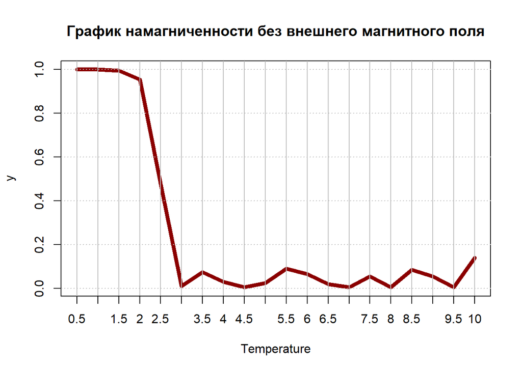

```r
plot(Temp,y, type='l', lwd=5, col='darkred', xlab = "Temperature", main="График намагниченности без внешнего магнитного поля")
abline(v=seq(0.5, 10, by=0.5), col="grey")
abline(h=seq(0, 1, by=0.2), col="grey", lty="dotted")
axis(1, at=Temp, labels=Temp)
```

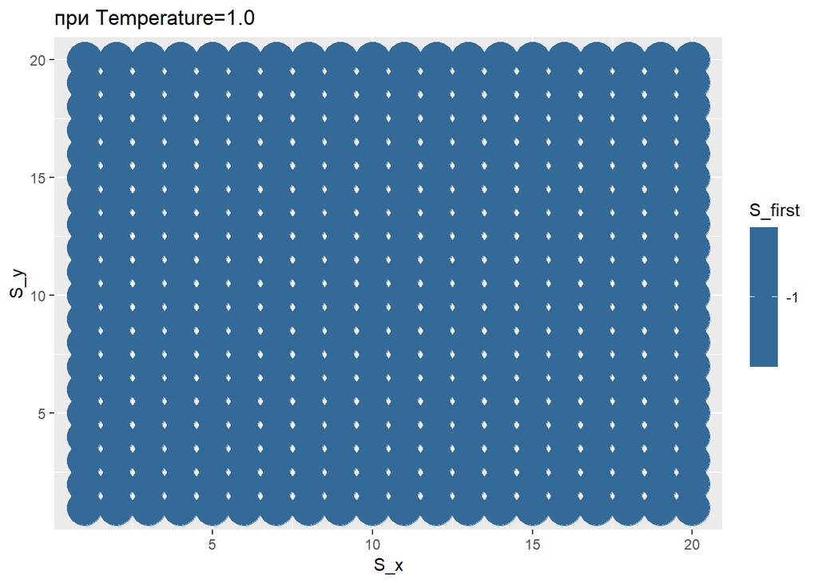

```r
library("ggplot2")
Nsteps <- 10^6
S_first <- sample(c(-1,1), N, replace=T)
T <- 1
beta <- 1/T
for (step in 1:Nsteps){
  z <- 1:N
  k <- sample(z, 1, replace=T)
  p <- c()
  for (i in cl[[k]])
  {p <- c(p,S_first[i])}
  E <- S_first[k]*sum(p)
  if(runif(1,0,1)<exp(-beta*2.0*E)){
    S_first[k] =S_first[k]*-1
  }
}
Nsteps <- 10^6
S2 <- sample(c(-1,1), N, replace=T)
T <- 2.0
beta <- 1/T
for (step in 1:Nsteps){
  z <- 1:N
  k <- sample(z, 1, replace=T)
  p <- c()
  for (i in cl[[k]])
  {p <- c(p,S2[i])}
  E <- S2[k]*sum(p)
  if(runif(1,0,1)<exp(-beta*2.0*E)){
    S2[k] =S2[k]*-1
  }
}

Nsteps <- 10^6
S3 <- sample(c(-1,1), N, replace=T)
T <- 2.2
beta <- 1/T
for (step in 1:Nsteps){
  z <- 1:N
  k <- sample(z, 1, replace=T)
  p <- c()
  for (i in cl[[k]])
  {p <- c(p,S3[i])}
  E <- S3[k]*sum(p)
  if(runif(1,0,1)<exp(-beta*2.0*E)){
    S3[k] =S3[k]*-1
  }
}

Nsteps <- 10^6
S4 <- sample(c(-1,1), N, replace=T)
T <- 3
beta <- 1/T
for (step in 1:Nsteps){
  z <- 1:N
  k <- sample(z, 1, replace=T)
  p <- c()
  for (i in cl[[k]])
  {p <- c(p,S4[i])}
  E <- S4[k]*sum(p)
  if(runif(1,0,1)<exp(-beta*2.0*E)){
    S4[k] =S4[k]*-1
  }
}

l <- c()
S_x <- c()
for (i in 1:L){
  l <- 1:L
  S_x <- c(S_x,l)
}
l <- c()
S_y <- c()
for (j in 1:L){
  J <- rep(j,L)
  S_y <- c(S_y,J)
}

df1 <- data.frame(S_first,S_x, S_y)
ggplot(df1, aes(S_x, S_y), main = "T = 1.0")+
  geom_point(size = 10, aes(color=S_first))+
  ggtitle("при Temperature=1.0")
```

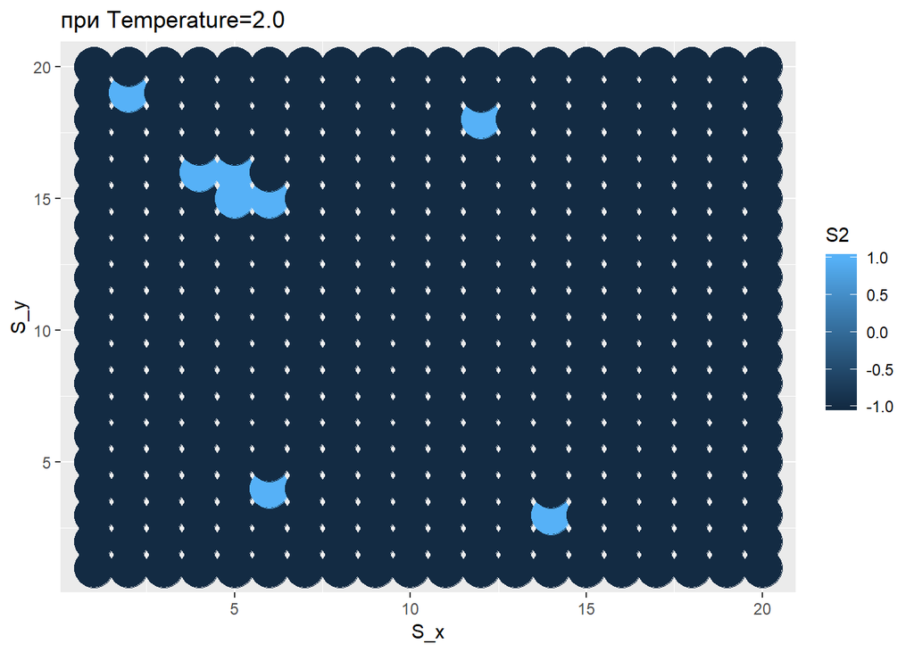

```r
df2 <- data.frame(S2,S_x, S_y)
ggplot(df2, aes(S_x, S_y))+
  geom_point(size = 10, aes(color=S2))+
  ggtitle("при Temperature=2.0")
```

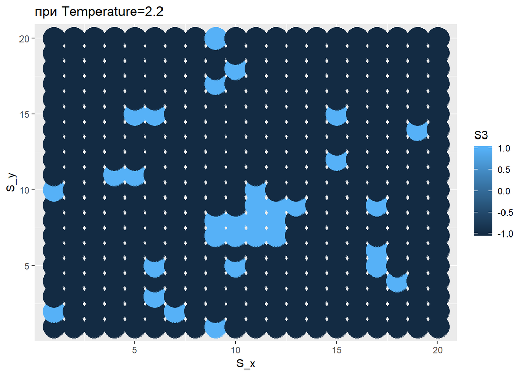

```r
df3 <- data.frame(S3,S_x, S_y)
ggplot(df3, aes(S_x, S_y))+
  geom_point(size = 10, aes(color=S3))+
  ggtitle("при Temperature=2.2")
```

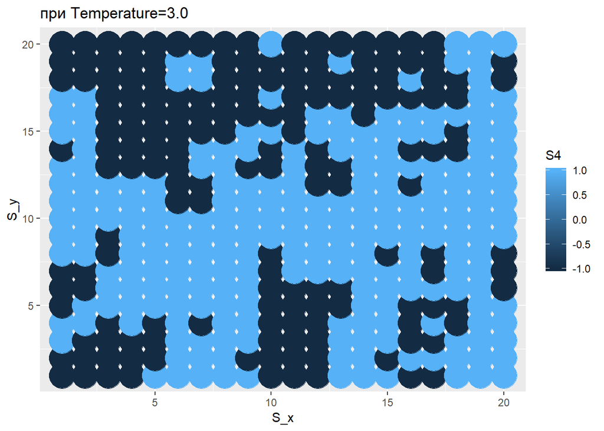

```r
df4 <- data.frame(S4,S_x, S_y)
ggplot(df4, aes(S_x, S_y))+
  geom_point(size = 10, aes(color=S4))+
  ggtitle("при Temperature=3.0")
```

Выше представлены характерные конфигурации модели Изинга при разных температурах. Видно, что при повышении температуры намагниченность пропадает, и единообразие спинов изменяется, они становятся хаотично направленными.

```r
set.seed(100)
Temp <- seq(from = 0.5, to=10, by=0.5)
H <- 1
Nsteps <- 10^6
S_M1 <- sample(c(-1,1), N, replace=T)
y_M1 <- c()
for (t in Temp){
  for (step in 1:Nsteps){
  T <- t
  beta <- 1.0/T
  z <- 1:N
  k <- sample(z, 1, replace=T)
  p <- c()
  for (i in cl[[k]])
  {p <- c(p,S_M1[i])}
  E <- S_M1[k]*sum(p)+S_M1[k]*H
  if(runif(1,0,1)<exp(-beta*2.0*E)){
    S_M1[k] =S_M1[k]*-1
  }
  }
  Sum_M1 <- abs(sum(S_M1))/N
  y_M1 <- c(y_M1,Sum_M1)
}
y_M1
```

```
##  [1] 1.000 1.000 1.000 0.995 0.960 0.880 0.850 0.655 0.520 0.400 0.405
## [12] 0.280 0.330 0.260 0.170 0.225 0.190 0.190 0.165 0.100
```

```r
set.seed(100)
Temp <- seq(from = 0.5, to=10, by=0.5)
H <- 2
Nsteps <- 10^6
S_M2 <- sample(c(-1,1), N, replace=T)
y_M2 <- c()
for (t in Temp){
  for (step in 1:Nsteps){
  T <- t
  beta <- 1.0/T
  z <- 1:N
  k <- sample(z, 1, replace=T)
  p <- c()
  for (i in cl[[k]])
  {p <- c(p,S_M2[i])}
  E <- S_M2[k]*sum(p)+S_M2[k]*H
  if(runif(1,0,1)<exp(-beta*2.0*E)){
    S_M2[k] =S_M2[k]*-1
  }
  }
  Sum_M2 <- abs(sum(S_M2))/N
  y_M2 <- c(y_M2,Sum_M2)
}
y_M2
```

```
##  [1] 1.000 1.000 1.000 1.000 0.985 0.930 0.925 0.860 0.735 0.665 0.690
## [12] 0.455 0.595 0.545 0.445 0.420 0.295 0.300 0.245 0.395
```

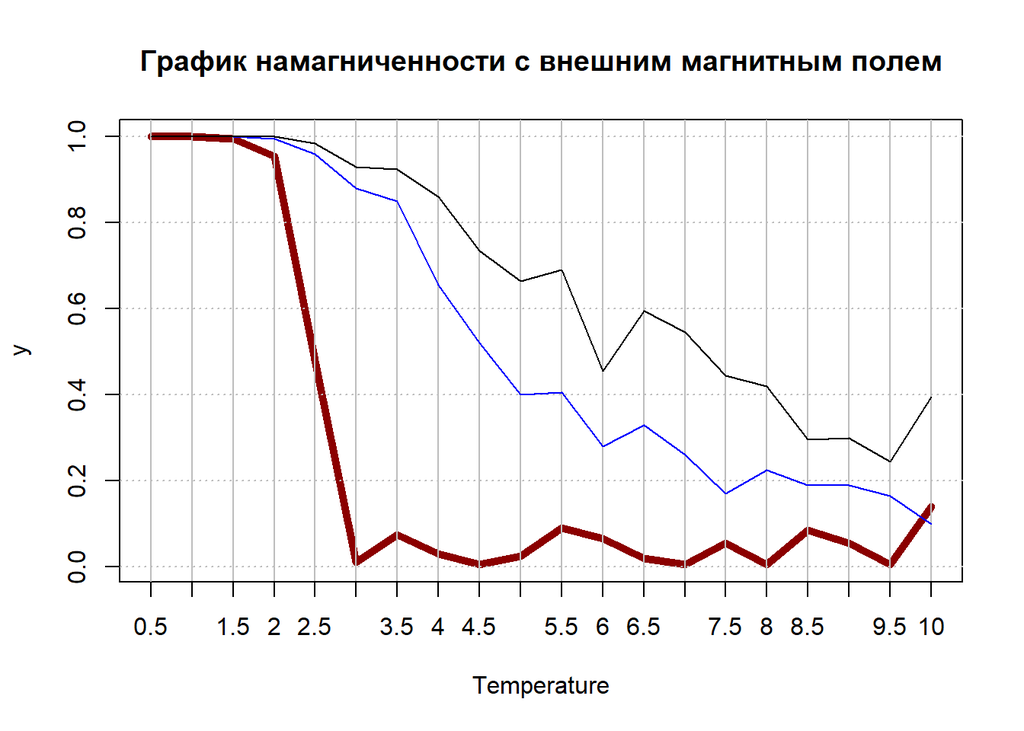

```r
plot(Temp,y, type='l', lwd=5, col='darkred', xlab = "Temperature", main="График намагниченности c внешним магнитным полем")
abline(v=seq(0.5, 10, by=0.5), col="grey")
abline(h=seq(0, 1, by=0.2), col="grey", lty="dotted")
axis(1, at=Temp, labels=Temp)
lines(Temp, y_M1, col = "blue")
lines(Temp, y_M2, col = "black")
```

Красной линией отмечен уровень намагниченности без внешнего поля. Синий - уровень намагниченности при внешнем поле H=1 Черной - уровень намагниченности при внешнем поле H=2 Как видно из графика, если добавить внешнее магнитное поле, то при $T<T_c$, поле как и при нулевом внешнем воздействии остается полностью намагниченным, однако чем выше внешнее поле, тем выше уровень намагниченности вещества, даже после достижения критической температуры.

При внешнем магнитном поле со следующей структурой: на половине решетки H=1, на другой половине H=-1 - ферромагнетик теряет магнетизацию. Это видно на графике ниже.

```r
set.seed(10)
L1 <- 10
N1 <- L1*L1
cl1 <- list()
v1 <- 0
a1 <- 0
b1<- 0
c1<- 0
d1<- 0
for (i in 1:N1){
  if (i%%L1==0){
    a1 <- i-(L1-1)}
  else
  {a1 <- i+1 }
  if (i+L1 < N1+1){
    b1 <- i+L1  }
  else
  {b1 <- i-(N1-L1)}
  if (i==1 | i%%L1==1)
  {c1 <- i+(L1-1)}
  else
  {c1 <- i-1}
  if(i+(N1-L1)< N1+1){
    d1 <- i+(N1-L1)  }
  else
  {d1 <- i-L1}
  v1 <- c(a1, b1, c1, d1)
  cl1[[i]] <- v1
}
L2 <- 10
N2 <- L2*L2
cl2 <- list()
v2 <- 0
a2 <- 0
b2 <- 0
c2 <- 0
d2 <- 0
for (i in 1:N2){
  if (i%%L2==0){
    a2 <- i-(L2-1)}
  else
  {a2 <- i+1 }
  if (i+L2 < N2+1){
    b2 <- i+L2  }
  else
  {b2 <- i-(N2-L2)}
  if (i==1 | i%%L2==1)
  {c2 <- i+(L2-1)}
  else
  {c2 <- i-1}
  if(i+(N2-L2)< N2+1){
    d2 <- i+(N2-L2)  }
  else
  {d2 <- i-L2}
  v2 <- c(a2, b2, c2, d2)
  cl2[[i]] <- v2
}

Temp <- seq(from = 0.5, to=10, by=0.5)
Nsteps <- 10^6
S_part1 <- sample(c(-1,1), N1, replace=T)
S_part2 <- sample(c(-1,1), N2, replace=T)
y_half <- c()
H_part1 <- 1
H_part2 <- -1
for (t in Temp){
  for (step in 1:Nsteps){
  T <- t
  beta <- 1.0/T
  z1 <- 1:N1
  k1 <- sample(z1, 1, replace=T)
  p1 <- c()
  for (i in cl1[[k1]])
  {p1 <- c(p1,S_part1[i])}
  E1 <- S_part1[k1]*sum(p1)+S_part1[k1]*H_part1
  if(runif(1,0,1)<exp(-beta*2.0*E1)){
    S_part1[k1] =S_part1[k1]*-1
  }
  z2 <- 1:N2
  k2 <- sample(z2, 1, replace=T)
  p2 <- c()
  for (i in cl2[[k2]])
  {p2 <- c(p2,S_part2[i])}
  E2 <- S_part2[k2]*sum(p2)+S_part2[k1]*H_part2
  if(runif(1,0,1)<exp(-beta*2.0*E2)){
    S_part2[k2] =S_part2[k2]*-1
  }
  }
  S_half <- c(S_part2, S_part2, S_part1, S_part1)
  N_half <- 2*(N1+N2)
  Sum_half <- abs(sum(S_half))/N_half
  y_half <- c(y_half, Sum_half)
}
y_half
```

```
##  [1] 0.00 0.00 0.00 0.01 0.01 0.49 0.22 0.56 0.25 0.19 0.29 0.31 0.00 0.08
## [15] 0.05 0.18 0.05 0.16 0.10 0.08
```

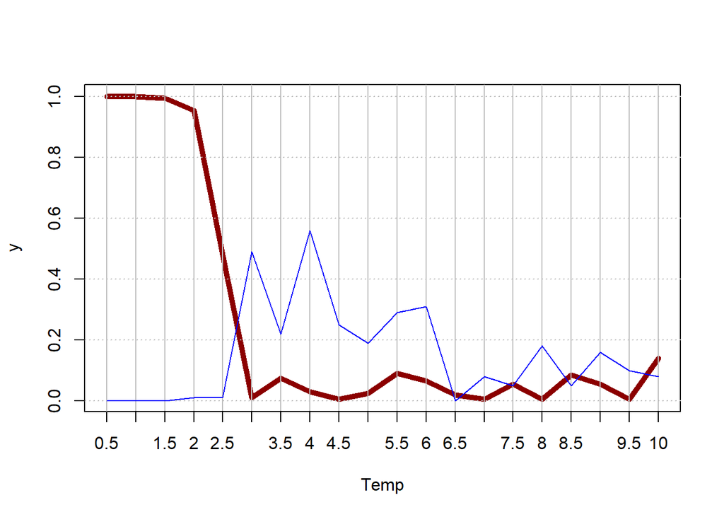

```r
plot(Temp,y, type='l', lwd=5, col='darkred')
abline(v=seq(0.5, 10, by=0.5), col="grey")
abline(h=seq(0, 1, by=0.2), col="grey", lty="dotted")
axis(1, at=Temp, labels=Temp)
lines(Temp, y_half, col = "blue")
```

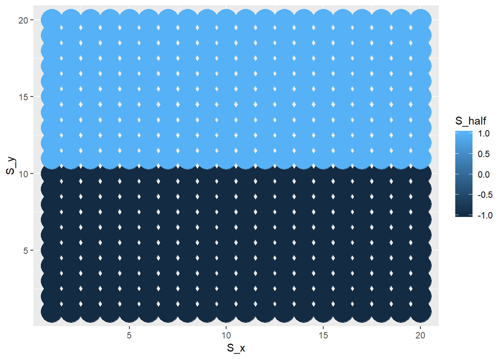

```r
set.seed(10)
L1 <- 10
N1 <- L1*L1
cl1 <- list()
v1 <- 0
a1 <- 0
b1<- 0
c1<- 0
d1<- 0
for (i in 1:N1){
  if (i%%L1==0){
    a1 <- i-(L1-1)}
  else
  {a1 <- i+1 }
  if (i+L1 < N1+1){
    b1 <- i+L1  }
  else
  {b1 <- i-(N1-L1)}
  if (i==1 | i%%L1==1)
  {c1 <- i+(L1-1)}
  else
  {c1 <- i-1}
  if(i+(N1-L1)< N1+1){
    d1 <- i+(N1-L1)  }
  else
  {d1 <- i-L1}
  v1 <- c(a1, b1, c1, d1)
  cl1[[i]] <- v1
}
L2 <- 10
N2 <- L2*L2
cl2 <- list()
v2 <- 0
a2 <- 0
b2 <- 0
c2 <- 0
d2 <- 0
for (i in 1:N2){
  if (i%%L2==0){
    a2 <- i-(L2-1)}
  else
  {a2 <- i+1 }
  if (i+L2 < N2+1){
    b2 <- i+L2  }
  else
  {b2 <- i-(N2-L2)}
  if (i==1 | i%%L2==1)
  {c2 <- i+(L2-1)}
  else
  {c2 <- i-1}
  if(i+(N2-L2)< N2+1){
    d2 <- i+(N2-L2)  }
  else
  {d2 <- i-L2}
  v2 <- c(a2, b2, c2, d2)
  cl2[[i]] <- v2
}

T <- 1.5
beta <- 1.0/T
Nsteps <- 10^6
S_part1 <- sample(c(-1,1), N1, replace=T)
S_part2 <- sample(c(-1,1), N2, replace=T)
y_half <- c()
H_part1 <- 1
H_part2 <- -1
for (step in 1:Nsteps){
  z1 <- 1:N1
  k1 <- sample(z1, 1, replace=T)
  p1 <- c()
  for (i in cl1[[k1]])
  {p1 <- c(p1,S_part1[i])}
  E1 <- S_part1[k1]*sum(p1)+S_part1[k1]*H_part1
  if(runif(1,0,1)<exp(-beta*2.0*E1)){
    S_part1[k1] =S_part1[k1]*-1
  }
  z2 <- 1:N2
  k2 <- sample(z2, 1, replace=T)
  p2 <- c()
  for (i in cl2[[k2]])
  {p2 <- c(p2,S_part2[i])}
  E2 <- S_part2[k2]*sum(p2)+S_part2[k1]*H_part2
  if(runif(1,0,1)<exp(-beta*2.0*E2)){
    S_part2[k2] =S_part2[k2]*-1
  }
}
S_half <- c(S_part2, S_part2, S_part1, S_part1)

df <- data.frame(S_half,S_x, S_y)
ggplot(df, aes(S_x, S_y))+
  geom_point(size = 10, aes(color=S_half))
```

# Задача №2.

Методом Монте-Карло оцените площадь единичной d-мерной гиперсферы. Исследуйте зависимость этой величины от размерности.

Гиперсфера - это гиперповерхность в n-мерном евклидовом пространстве, образованная точками, равноудалёнными от заданной точки, называемой центром сферы. Расстояние от центра гиперсферы до её поверхности называется радиусом гиперсферы. В задании рассматривается гиперсфера с радиусом 1.

Необходимо оценить ее площадь как многомерный интеграл. Уравнение сферы в декартовой системе координат имеет вид $x^2+y^2+z^2=R^2$ Мы знаем, что когда уравнение площади поверхности задано неявным образом, интеграл для вычисления этой поверхности принимает вид:

$S = \int\limits_{(D)}\int\frac{\sqrt{A^2+B^2+C^2}}{|C|}dxdy$ где $A=\frac{dF}{dx}, B=\frac{dF}{dy}, C=\frac{dF}{dz}$

Следовательно, для уравнения сферы имеем $A=2x, B=2y, C=2z$

Тогда площадь сферы с учетом симметрии определяется двойным интегралом:

$S = 8\int\limits_{(D)}\int\frac{\sqrt{x^2+y^2+z^2}}{|z|}dxdy=8R \int\limits_{(D)}\int\frac{1}{\sqrt{R^2-x^2-y^2}}dxdy$ То можно обобщить эту формулу на n-мерный случай единичнйо сферы, $S_{d-1} = 2^d\int\limits_{(D)}\int\frac{1}{\sqrt{1-x_1^2-x_2^2....x_n^2}}dx_1dx_2...dx_n$

В таком случае методом Монте Карло возможно оценить площади d-мерных сфер.

```r
n <- 10^7
m <- list()
for (i in 1:25){
  l <- c(runif(n, -1, 1))
  m[[i]] <- l
}

t <- rep(0, 25)
for (d in 2:25){
  x <- m[[d]]
  if(d==2){
  k <- 1-x^2
  }
  else
  {s <- x^2
  k <- k-s}
  I <- 1/sqrt(k)
  Isum <- 2^d*sum(I, na.rm = TRUE)/n
  t[d] <- Isum
}
```

[output not shown]

```r
t
```

```
##  [1]  0.0000000  6.2795799 12.5822893 19.7241510 26.3379053 31.0037681
##  [7] 33.3561351 32.5013543 29.8582883 25.5625522 20.7540230 15.5048279
## [13] 11.7127816  8.6592489  5.5270523  3.4946323  2.0580653  1.1826810
## [19]  0.2585796  0.0000000  0.0000000  0.0000000  0.0000000  0.0000000
## [25]  0.0000000
```

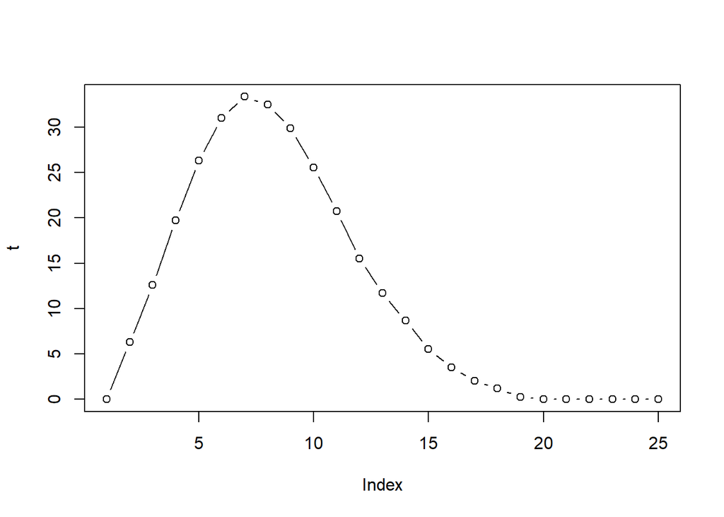

```r
plot(t, type='b')
```

Если взять выведенную формулу для площади гиперсферы с Гамма-функцией, то получим точные значения, которые можно сравнить с симуляцией. $S_{d-1} = \frac{\Pi^{d/2}*d}{Г(1+d/2)}$

$Г(1+d/2) = \int_0^\infty z^{d/2}e^{-z}dz$

$Г(d/2) = \int_0^\infty z^{d/2-1}e^{-z}dz = EZ^{d/2-1}$

$EZ^{d/2-1} = \frac{1}{N}\sum_{i=1}z_i^{d/2-1}$ где $z_i \sim Exp(1)$

```r
nn <- 10^7
t2 <- rep(0, 25)
for (d in 2:25){
x <- rexp(nn,1)
I <- sum(x^((d/2)-1))/nn
F <- (2*pi^(d/2))/I
t2[d] <- F
}
t2
```

```
##  [1]  0.00000000  6.28318531 12.57040291 19.73558843 26.30572740
##  [6] 31.03893872 33.06827104 32.52162726 29.72091017 25.47771408
## [11] 20.85938278 16.02084829 11.73671045  8.46981919  5.74021438
## [16]  3.68731796  2.41256582  1.52589672  0.90947474  0.53128701
## [21]  0.30376832  0.18734195  0.09734253  0.05138931  0.02756332
```

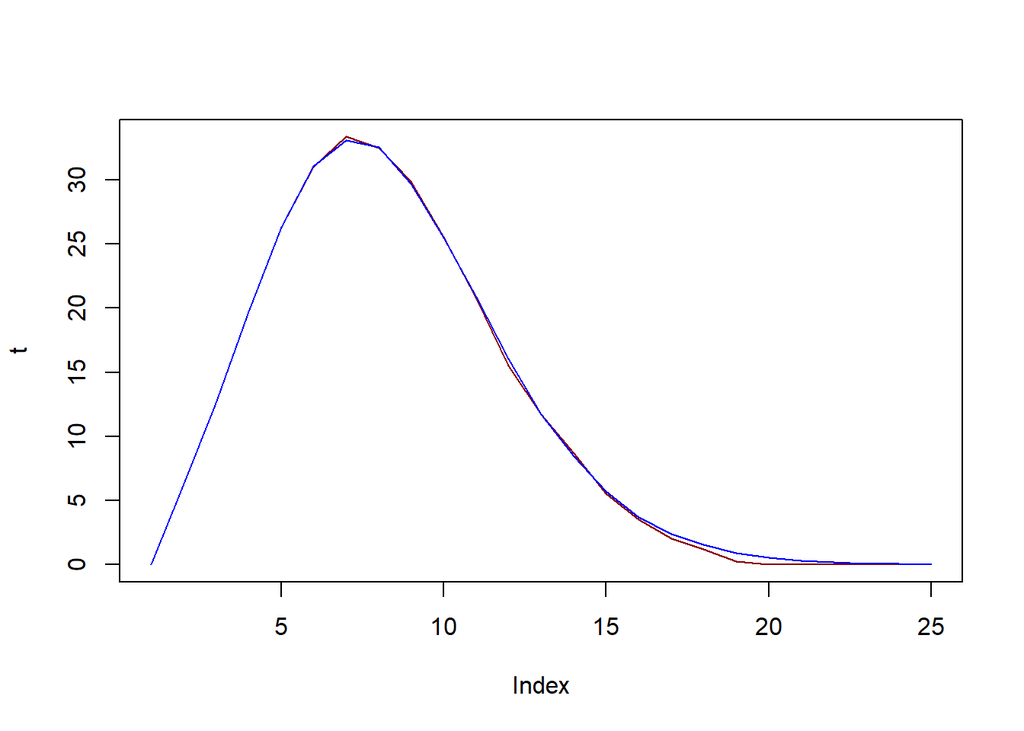

```r
plot(t, type='l', col='darkred')
lines(t2, col = "blue")
```

Как можно видеть из графика, при большом числе симуляций, метод Монте-Карло дает хорошие результаты, однако с ростом размерности, точность ухудшается.